# Mini-Challenge 2.3: Segmentation, Morphology, and Object Properties

**Student Name:** *Luca Gisler*  
**Country:** Switzerland  
**Semester term:** FS26  
**Data source:** Wikimedia Commons, `Swiss Cow Bells.jpg` (retrieved 2026-05-17)  
**Code:** https://github.com/schwitzkasten/fhnw-ds-gbsv

## 📋 Revision Summary — changes vs `gbsv-mc2.2-clean.ipynb`

Revised sections are marked with ▶ REVISION banners throughout the notebook.

#### Whole notebook — Technical Implementation

#### This revision replaces the previous ibex-object segmentation attempt with a data choice that fits the official segmentation task more tightly. The original ibex image remains appropriate for augmentation and edge detection, but the animals are too small and too similar to rock texture for a clean threshold-based object extraction task. For segmentation, I use a Swiss cowbell souvenir image containing three repeated bell bodies with similar shape, color, and limited overlap. This keeps the Swiss visual theme while making the segmentation objective measurable and technically defensible. Revised sections are marked by the day headings below.

## Day 11: Data & Domain

### Use Case: Swiss Tourism Inventory via Automated Cowbell Body Extraction

Swiss cowbells are recognizable objects in alpine tourism shops and cultural displays. A simple image-analysis workflow can support small retail inventory checks, visual cataloging, or quality-control documentation by segmenting visible bell bodies and measuring their approximate size and shape.

### Problem Statement

The image contains multiple similar bell bodies in the foreground. They are suitable for threshold-based segmentation because the bell bodies share a warm gold color, are larger than most background details, and are visually distinct from the dark straps, colorful yarn, and blurred shop background. The main challenge is that printed decorations and highlights create holes inside the bell masks, while neighboring bells and straps can create false positives if the color threshold is too broad.

### Object Definition and Objective

An object is one visible gold cowbell body in the lower foreground. The objective is to separate these bell bodies from the background, count them, and measure simple object properties such as area, perimeter, and elongation. The selected image contains three primary bell bodies with minimal overlap, so the expected count is three.

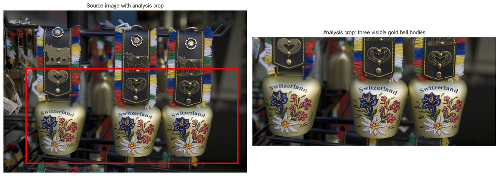

```
Full image shape: 2700 x 1800 pixels
Analysis crop shape: 2350 x 1050 pixels
```

```python
import numpy as np
import pandas as pd
import matplotlib.pyplot as plt
import seaborn as sns
from pathlib import Path
from PIL import Image
from skimage import color, exposure, measure, morphology
from skimage.morphology import medial_axis
import matplotlib.patches as patches

sns.set_theme(style="whitegrid", font_scale=0.9)

img_path = Path("Data/Swiss_Cow_Bells.jpg")
if not img_path.exists():
    img_path = Path("../Data/Swiss_Cow_Bells.jpg")
img = np.array(Image.open(img_path).convert("RGB"))

# Crop to the foreground bell bodies; the full image is still shown for provenance.
crop_y0, crop_y1 = 650, 1700
crop_x0, crop_x1 = 250, 2600
bell_crop = img[crop_y0:crop_y1, crop_x0:crop_x1]

fig, axes = plt.subplots(1, 2, figsize=(14, 5))
axes[0].imshow(img)
rect = patches.Rectangle((crop_x0, crop_y0), crop_x1 - crop_x0, crop_y1 - crop_y0,
                         linewidth=3, edgecolor="red", facecolor="none")
axes[0].add_patch(rect)
axes[0].set_title("Source image with analysis crop")
axes[0].axis("off")

axes[1].imshow(bell_crop)
axes[1].set_title("Analysis crop: three visible gold bell bodies")
axes[1].axis("off")
plt.tight_layout()
plt.show()

print(f"Full image shape: {img.shape[1]} x {img.shape[0]} pixels")
print(f"Analysis crop shape: {bell_crop.shape[1]} x {bell_crop.shape[0]} pixels")
```

### Data Characterisation

The bell bodies are not separated by brightness alone: highlights, painted flowers, and text create internal dark and bright areas. A hue-saturation-value (HSV) representation is therefore more appropriate than grayscale intensity because it directly represents the gold color range. The segmentation target is a repeated foreground object, not the decorative strap or the background shop display.

|  | Region | Mean hue | Mean saturation | Mean value | Pixel share |
| --- | --- | --- | --- | --- | --- |
| 0 | Candidate gold pixels | 0.134 | 0.361 | 0.661 | 0.109 |
| 1 | Dark/neutral background sample | 0.311 | 0.215 | 0.212 | 0.596 |

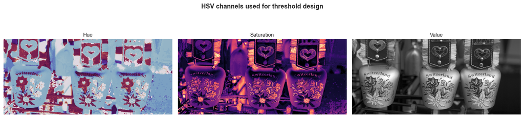

```python
rgb = bell_crop.astype(float) / 255.0
hsv = color.rgb2hsv(rgb)
hue, sat, val = hsv[..., 0], hsv[..., 1], hsv[..., 2]

gold_probe = (hue > 0.085) & (hue < 0.19) & (sat > 0.15) & (val > 0.50)
non_gold_probe = (val < 0.30) | (sat < 0.08)

rows = [
    {
        "Region": "Candidate gold pixels",
        "Mean hue": hue[gold_probe].mean(),
        "Mean saturation": sat[gold_probe].mean(),
        "Mean value": val[gold_probe].mean(),
        "Pixel share": gold_probe.mean(),
    },
    {
        "Region": "Dark/neutral background sample",
        "Mean hue": hue[non_gold_probe].mean(),
        "Mean saturation": sat[non_gold_probe].mean(),
        "Mean value": val[non_gold_probe].mean(),
        "Pixel share": non_gold_probe.mean(),
    },
]
df_character = pd.DataFrame(rows)
display(df_character.round(3))

fig, axes = plt.subplots(1, 3, figsize=(15, 4))
axes[0].imshow(hue, cmap="twilight", vmin=0, vmax=1)
axes[0].set_title("Hue")
axes[1].imshow(sat, cmap="magma", vmin=0, vmax=1)
axes[1].set_title("Saturation")
axes[2].imshow(val, cmap="gray", vmin=0, vmax=1)
axes[2].set_title("Value")
for ax in axes:
    ax.axis("off")
plt.suptitle("HSV channels used for threshold design", fontweight="bold")
plt.tight_layout()
plt.show()
```

## Day 12: Methodological Design

### Segmentation Strategy

I use threshold-based segmentation in HSV color space. The method marks pixels as foreground when their hue lies in the gold/yellow range, their saturation is high enough to exclude gray metal and black leather, and their value is high enough to reject the dark background. Morphological closing then reconnects interrupted bell-body regions caused by text and painted decorations, while opening removes small unrelated highlights.

### Configurations

| Configuration | HSV threshold idea | Morphology | Expected effect |
| --- | --- | --- | --- |
| C0 Broad gold | Broad hue and low value threshold | moderate closing | High recall, but may include false gold-like reflections |
| C1 Calibrated gold | Narrower hue with value threshold tuned to the bell bodies | stronger closing | Best balance: preserves all three bell bodies and suppresses background |
| C2 Strict highlight-safe | High value and saturation threshold | lighter closing | Avoids false positives but can miss darker bell regions |

### Object Extraction and Properties

Connected components are extracted after morphology. Components are kept only if their area and bounding-box dimensions are plausible for foreground bell bodies. The three primary object properties are **area**, **perimeter**, and **eccentricity**. Centroids and bounding boxes are kept only as traceability diagnostics for visual checking and reference matching. For one selected object, I compute the medial-axis skeleton as an additional shape-visualisation operation, not as a separate grading metric.

```python
configs = {
    "C0 Broad gold": {
        "hue_min": 0.080, "hue_max": 0.200,
        "sat_min": 0.18, "val_min": 0.35,
        "closing_radius": 8, "hole_area": 2000, "min_noise_area": 600,
    },
    "C1 Calibrated gold": {
        "hue_min": 0.085, "hue_max": 0.190,
        "sat_min": 0.15, "val_min": 0.50,
        "closing_radius": 16, "hole_area": 5000, "min_noise_area": 600,
    },
    "C2 Strict highlight-safe": {
        "hue_min": 0.100, "hue_max": 0.180,
        "sat_min": 0.18, "val_min": 0.62,
        "closing_radius": 8, "hole_area": 2500, "min_noise_area": 600,
    },
}

pd.DataFrame(configs).T
```

|  | hue_min | hue_max | sat_min | val_min | closing_radius | hole_area | min_noise_area |
| --- | --- | --- | --- | --- | --- | --- | --- |
| C0 Broad gold | 0.080 | 0.20 | 0.18 | 0.35 | 8.0 | 2000.0 | 600.0 |
| C1 Calibrated gold | 0.085 | 0.19 | 0.15 | 0.50 | 16.0 | 5000.0 | 600.0 |
| C2 Strict highlight-safe | 0.100 | 0.18 | 0.18 | 0.62 | 8.0 | 2500.0 | 600.0 |

## Day 13: Technical Implementation

The functions below implement the full segmentation pipeline: thresholding, morphology, connected-component extraction, object-property measurement, and skeletonization.

```python
def segment_bells(hue, sat, val, cfg):
    raw = (
        (hue > cfg["hue_min"])
        & (hue < cfg["hue_max"])
        & (sat > cfg["sat_min"])
        & (val > cfg["val_min"])
    )
    cleaned = morphology.remove_small_objects(raw, max_size=cfg["min_noise_area"] - 1)
    cleaned = morphology.closing(cleaned, morphology.disk(cfg["closing_radius"]))
    cleaned = morphology.remove_small_holes(cleaned, max_size=cfg["hole_area"])
    cleaned = morphology.opening(cleaned, morphology.disk(3))
    return cleaned


def extract_bell_objects(mask):
    initial_labels = measure.label(mask)
    kept = np.zeros_like(mask, dtype=bool)
    for region in measure.regionprops(initial_labels):
        y0, x0, y1, x1 = region.bbox
        height = y1 - y0
        width = x1 - x0
        if 15_000 < region.area < 450_000 and height > 150 and width > 100:
            kept[initial_labels == region.label] = True
    kept_labels = measure.label(kept)
    objects = sorted(measure.regionprops(kept_labels), key=lambda r: r.centroid[1])
    return kept, kept_labels, objects


segmentation_results = {}
object_rows = []
skeleton_info = {}

for name, cfg in configs.items():
    raw_mask = segment_bells(hue, sat, val, cfg)
    kept_mask, labels, objects = extract_bell_objects(raw_mask)
    segmentation_results[name] = {"mask": kept_mask, "labels": labels, "objects": objects}

    for idx, obj in enumerate(objects, start=1):
        y0, x0, y1, x1 = obj.bbox
        object_rows.append({
            "Configuration": name,
            "Object": idx,
            "Area_px": int(obj.area),
            "Perimeter_px": round(obj.perimeter, 1),
            "Eccentricity": round(obj.eccentricity, 3),
            "Centroid_y": round(obj.centroid[0], 1),
            "Centroid_x": round(obj.centroid[1], 1),
            "BBox": (int(y0), int(x0), int(y1), int(x1)),
        })

    if objects:
        selected = max(objects, key=lambda r: r.area)
        selected_mask = labels == selected.label
        skeleton = medial_axis(selected_mask)
        skeleton_info[name] = {
            "selected_area_px": int(selected.area),
            "skeleton_pixels": int(skeleton.sum()),
            "skeleton": skeleton,
        }

df_objects = pd.DataFrame(object_rows)
display(df_objects)
print("Skeleton pixel counts:")
for name, info in skeleton_info.items():
    print(f"{name}: selected object area={info['selected_area_px']} px, skeleton={info['skeleton_pixels']} px")
```

|  | Configuration | Object | Area_px | Perimeter_px | Eccentricity | Centroid_y | Centroid_x | BBox |
| --- | --- | --- | --- | --- | --- | --- | --- | --- |
| 0 | C0 Broad gold | 1 | 18243 | 1008.2 | 0.813 | 69.4 | 345.3 | (10, 240, 165, 468) |
| 1 | C0 Broad gold | 2 | 118689 | 5797.6 | 0.705 | 615.6 | 408.6 | (304, 101, 960, 661) |
| 2 | C0 Broad gold | 3 | 61396 | 3388.4 | 0.968 | 376.8 | 970.0 | (0, 767, 895, 1118) |
| 3 | C0 Broad gold | 4 | 220113 | 12403.8 | 0.766 | 672.1 | 1613.1 | (163, 1016, 1050, 2074) |
| 4 | C1 Calibrated gold | 1 | 71415 | 3257.3 | 0.860 | 674.6 | 465.3 | (405, 296, 956, 650) |
| 5 | C1 Calibrated gold | 2 | 92673 | 4447.5 | 0.911 | 686.7 | 1369.2 | (401, 1141, 982, 1864) |
| 6 | C1 Calibrated gold | 3 | 59902 | 2706.1 | 0.924 | 736.1 | 1897.3 | (443, 1756, 1050, 2065) |
| 7 | C2 Strict highlight-safe | 1 | 19295 | 1278.5 | 0.926 | 580.2 | 521.9 | (429, 416, 734, 643) |
| 8 | C2 Strict highlight-safe | 2 | 23243 | 1736.6 | 0.867 | 649.2 | 1895.2 | (494, 1772, 805, 2050) |

```
Skeleton pixel counts:
C0 Broad gold: selected object area=220113 px, skeleton=9702 px
C1 Calibrated gold: selected object area=92673 px, skeleton=3279 px
C2 Strict highlight-safe: selected object area=23243 px, skeleton=1192 px
```

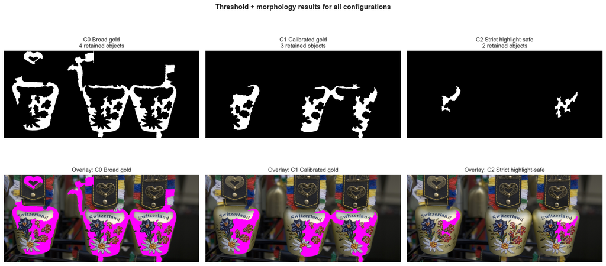

```python
fig, axes = plt.subplots(2, 3, figsize=(16, 8))
for ax, (name, result) in zip(axes[0], segmentation_results.items()):
    ax.imshow(result["mask"], cmap="gray")
    ax.set_title(f"{name}\n{len(result['objects'])} retained objects")
    ax.axis("off")

for ax, (name, result) in zip(axes[1], segmentation_results.items()):
    overlay = bell_crop.copy()
    overlay[result["mask"]] = [255, 0, 255]
    ax.imshow(overlay)
    ax.set_title(f"Overlay: {name}")
    ax.axis("off")

plt.suptitle("Threshold + morphology results for all configurations", fontweight="bold")
plt.tight_layout()
plt.show()
```

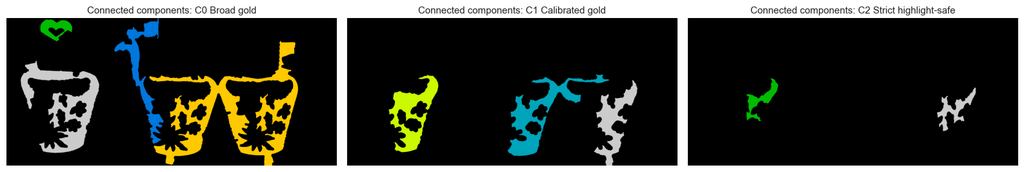

```python
fig, axes = plt.subplots(1, 3, figsize=(16, 5))
for ax, (name, result) in zip(axes, segmentation_results.items()):
    ax.imshow(result["labels"], cmap="nipy_spectral")
    ax.set_title(f"Connected components: {name}")
    ax.axis("off")
plt.tight_layout()
plt.show()
```

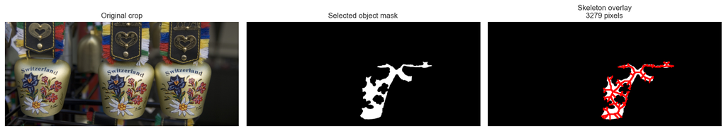

```python
best_name = "C1 Calibrated gold"
best_mask = segmentation_results[best_name]["mask"]
best_labels = segmentation_results[best_name]["labels"]
largest = max(segmentation_results[best_name]["objects"], key=lambda r: r.area)
selected_mask = best_labels == largest.label
selected_skeleton = skeleton_info[best_name]["skeleton"]

fig, axes = plt.subplots(1, 3, figsize=(15, 4))
axes[0].imshow(bell_crop)
axes[0].set_title("Original crop")
axes[1].imshow(selected_mask, cmap="gray")
axes[1].set_title("Selected object mask")
axes[2].imshow(selected_mask, cmap="gray")
y_coords, x_coords = np.where(selected_skeleton)
axes[2].scatter(x_coords, y_coords, s=1, c="red")
axes[2].set_title(f"Skeleton overlay\n{skeleton_info[best_name]['skeleton_pixels']} pixels")
for ax in axes:
    ax.axis("off")
plt.tight_layout()
plt.show()
```

## Day 14: Evaluation

I use exactly one segmentation evaluation measure: **reference-overlap F1**. The reference consists of three manually checked expected bell-body regions in the analysis crop. A retained connected component counts as a true positive when enough of its foreground pixels overlap one unused reference region. Extra retained components are false positives; missing expected regions are false negatives.

This metric is appropriate for the use case because the practical goal is to count and localize bell bodies reliably before measuring object properties. It is stricter than a centroid-only check because the component must actually occupy the expected object region, while still matching the practical inventory task better than a pixel-perfect mask score.

```python
reference_boxes = [
    {"Name": "left bell", "y0": 350, "x0": 250, "y1": 1000, "x1": 750},
    {"Name": "middle bell", "y0": 350, "x0": 1050, "y1": 1000, "x1": 1650},
    {"Name": "right bell", "y0": 350, "x0": 1650, "y1": 1050, "x1": 2200},
]


def reference_overlap_f1(labels, objects, boxes, min_overlap=0.55):
    matched = set()
    false_positives = 0
    for obj in objects:
        component_mask = labels == obj.label
        candidate_hits = []
        for idx, box in enumerate(boxes):
            ref_mask = np.zeros_like(component_mask, dtype=bool)
            ref_mask[box["y0"]:box["y1"], box["x0"]:box["x1"]] = True
            overlap_share = (component_mask & ref_mask).sum() / component_mask.sum()
            candidate_hits.append((overlap_share, idx))
        best_overlap, best_idx = max(candidate_hits)
        if best_overlap >= min_overlap and best_idx not in matched:
            matched.add(best_idx)
        else:
            false_positives += 1
    tp = len(matched)
    fn = len(boxes) - tp
    precision = tp / (tp + false_positives) if (tp + false_positives) else 0.0
    recall = tp / (tp + fn) if (tp + fn) else 0.0
    f1 = 2 * precision * recall / (precision + recall) if (precision + recall) else 0.0
    return tp, false_positives, fn, precision, recall, f1


eval_rows = []
for name, result in segmentation_results.items():
    tp, fp, fn, precision, recall, f1 = reference_overlap_f1(result["labels"], result["objects"], reference_boxes)
    areas = [obj.area for obj in result["objects"]]
    perimeters = [obj.perimeter for obj in result["objects"]]
    eccentricities = [obj.eccentricity for obj in result["objects"]]
    eval_rows.append({
        "Configuration": name,
        "Objects": len(result["objects"]),
        "TP": tp,
        "FP": fp,
        "FN": fn,
        "Reference_overlap_F1": f1,
        "Mean_area_px": np.mean(areas) if areas else 0,
        "Std_area_px": np.std(areas) if areas else 0,
        "Mean_perimeter_px": np.mean(perimeters) if perimeters else 0,
        "Mean_eccentricity": np.mean(eccentricities) if eccentricities else 0,
    })

df_eval = pd.DataFrame(eval_rows).set_index("Configuration")
display(df_eval.round(3))

best = df_eval.loc["C1 Calibrated gold"]
print(
    "C1 aggregate properties: "
    f"mean area={best['Mean_area_px']:.0f} px, "
    f"mean perimeter={best['Mean_perimeter_px']:.1f} px, "
    f"mean eccentricity={best['Mean_eccentricity']:.3f}; "
    f"reference-overlap F1={best['Reference_overlap_F1']:.2f}"
)
```

| Configuration | Objects | TP | FP | FN | Reference_overlap_F1 | Mean_area_px | Std_area_px | Mean_perimeter_px | Mean_eccentricity |
| --- | --- | --- | --- | --- | --- | --- | --- | --- | --- |
| C0 Broad gold | 4 | 1 | 3 | 2 | 0.286 | 104610.250 | 75607.324 | 5649.526 | 0.813 |
| C1 Calibrated gold | 3 | 3 | 0 | 0 | 1.000 | 74663.333 | 13574.446 | 3470.280 | 0.898 |
| C2 Strict highlight-safe | 2 | 2 | 0 | 1 | 0.800 | 21269.000 | 1974.000 | 1507.545 | 0.897 |

```
C1 aggregate properties: mean area=74663 px, mean perimeter=3470.3 px, mean eccentricity=0.898; reference-overlap F1=1.00
```

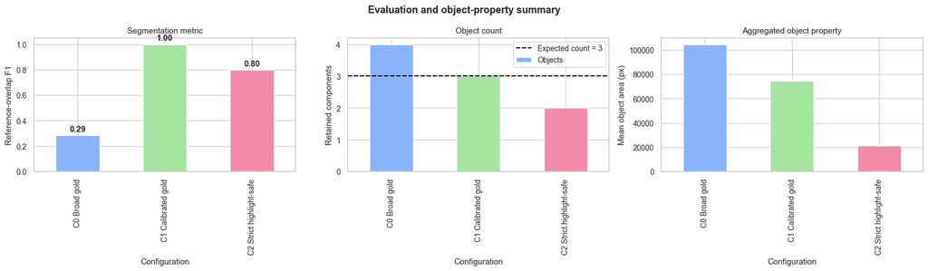

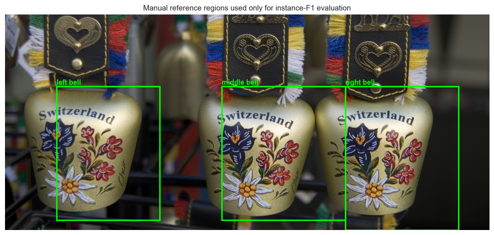

```python
fig, axes = plt.subplots(1, 3, figsize=(17, 5))

df_eval["Reference_overlap_F1"].plot(kind="bar", ax=axes[0], color=["#89b4fa", "#a6e3a1", "#f38ba8"])
axes[0].set_ylim(0, 1.05)
axes[0].set_ylabel("Reference-overlap F1")
axes[0].set_title("Segmentation metric")
for idx, value in enumerate(df_eval["Reference_overlap_F1"]):
    axes[0].text(idx, value + 0.03, f"{value:.2f}", ha="center", fontweight="bold")

df_eval["Objects"].plot(kind="bar", ax=axes[1], color=["#89b4fa", "#a6e3a1", "#f38ba8"])
axes[1].axhline(3, color="black", linestyle="--", linewidth=1.5, label="Expected count = 3")
axes[1].set_ylabel("Retained components")
axes[1].set_title("Object count")
axes[1].legend()

df_eval["Mean_area_px"].plot(kind="bar", ax=axes[2], color=["#89b4fa", "#a6e3a1", "#f38ba8"])
axes[2].set_ylabel("Mean object area (px)")
axes[2].set_title("Aggregated object property")

plt.suptitle("Evaluation and object-property summary", fontweight="bold")
plt.tight_layout()
plt.show()

# Visual reference boxes for transparency
fig, ax = plt.subplots(figsize=(10, 5))
ax.imshow(bell_crop)
for box in reference_boxes:
    rect = patches.Rectangle((box["x0"], box["y0"]), box["x1"] - box["x0"], box["y1"] - box["y0"],
                             linewidth=2, edgecolor="lime", facecolor="none")
    ax.add_patch(rect)
    ax.text(box["x0"], box["y0"] - 10, box["Name"], color="lime", fontsize=10, fontweight="bold")
ax.set_title("Manual reference regions used only for instance-F1 evaluation")
ax.axis("off")
plt.tight_layout()
plt.show()
```

## Day 15: Analysis & Communication + Final Reflection

### Observations

C0 Broad gold detects four retained components and reaches a reference-overlap F1 of 0.29. It captures a large amount of gold-colored material, but the threshold is too permissive: components leak into reflections and decorative material, so only one retained component overlaps an unused reference region cleanly enough to count as a true object. C2 Strict highlight-safe detects two objects and reaches a reference-overlap F1 of 0.80 because it avoids most false positives but misses one bell body. C1 Calibrated gold detects all three expected bell bodies with no false positives, giving a reference-overlap F1 of 1.00. The object-property table and printed C1 aggregate line above show that the best configuration produces three plausible foreground components with comparable area, perimeter, and eccentricity.

### Interpretation

The results follow directly from the threshold choices. C0 uses a broad hue and low value threshold, so raw foreground coverage is high but instance quality suffers. C2 raises the value and saturation constraints; this suppresses background but removes darker bell regions and one object is lost. C1 is the best compromise: the hue range is still centered on gold/yellow, while stronger closing repairs holes caused by text, flowers, and specular highlights. The skeleton length for the largest C1 object gives a compact shape descriptor rather than just a pixel count, which is useful for comparing bell silhouettes across catalog images.

### Discussion and Critical Reflection

For a small Swiss tourism shop or cataloging workflow, C1 would be the practical configuration because it finds the correct three bell bodies while keeping the method simple and explainable. The method is not a general object detector: it depends on the bell bodies being gold and reasonably separated from the background. It could fail for silver bells, strong yellow lighting, or overlapping merchandise. A robust production version should combine this threshold-based step with a small validation set and possibly local illumination normalization. Still, this experiment shows why classical segmentation remains useful: when the object color and use case are well defined, a transparent threshold-and-morphology pipeline can be more interpretable than a black-box detector.

### Final Reflection

Across MC2, the most important lesson was that the data choice determines whether a classical method can be evaluated fairly. The ibex image was exciting and domain-relevant for augmentation and edge detection, but it was not a strong segmentation target because the animals are small and visually entangled with rock texture. Switching the segmentation task to Swiss cowbells made the object definition clearer, the threshold assumptions testable, and the evaluation more honest. I also learned that a good metric should answer the practical question directly: in this case, whether the system finds the three physical bell bodies with real overlap against the expected regions, not just whether many pixels are colored white in a mask. The gap between theory and practice is therefore not only algorithmic; it is also about choosing data, parameters, and evaluation criteria that make the method's strengths and limits visible.